# Assignment 1

2. October 2015

## Introduction

This is an R Markdown presentation by Christopher and Lisa. It presents the results of the analyses run as part of Assignment 1.

The data used for the analysis is (1) the preinstalled "*WWWusage*" and (2) the "*HairEyeColor*" data. The first one is a time series of the numbers of users connected to the Internet through a server every minute. The second one is a cross-sectional data set describing the hair and eye color as well as sex of 592 statistics students.

Let's start with the first one.

## WWWusage: Line Chart

This is a line chart of the time series data. The number of users is lowest (1) in the beginning, increases at the 10th minute and has three spikes until it decreases again at minute 55. Another increase happens at minute 78, until the number of users reaches its peak, which is 228 users.

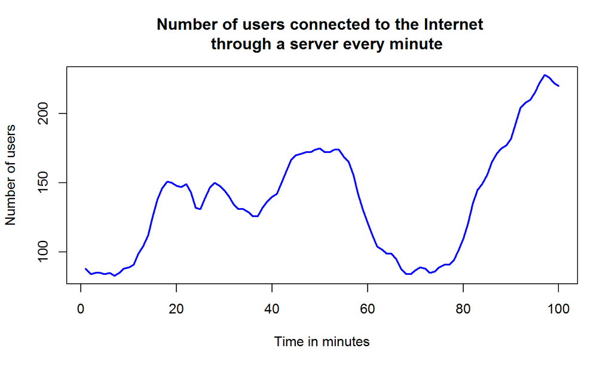

## WWWusage: Mean

The mean of the time series is 137.08. Let's plot this together with the time series.

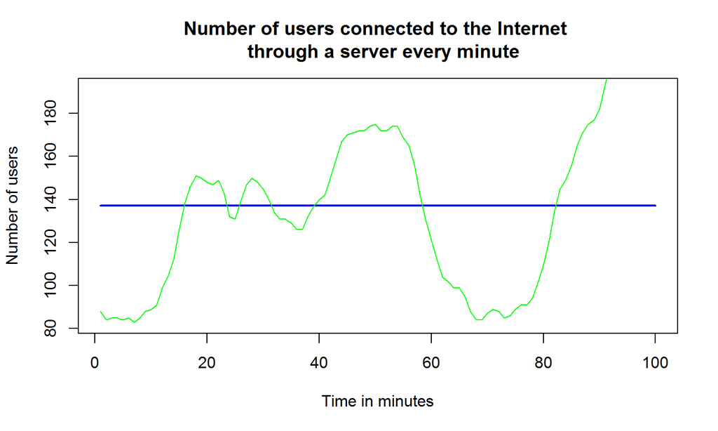

## WWWusage: Log

Now let's plot the difference in log of the time series to get the percentage change. The time series now seems to be very close to stationary data.

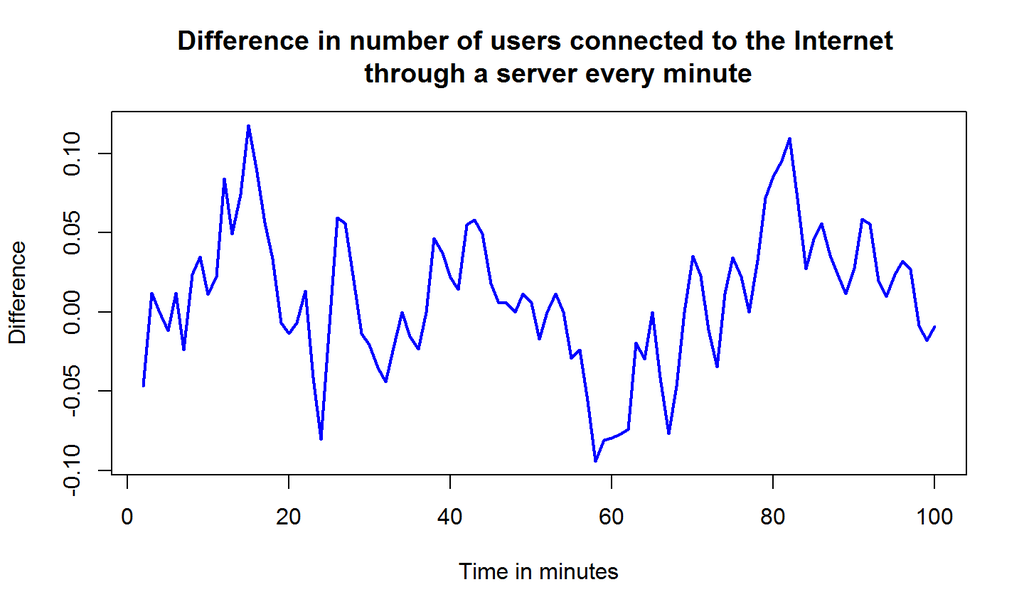

## WWWusage: Rescaling

Now we plot specific parts of the time series which allows for rescaling, in this case the first 10 observations

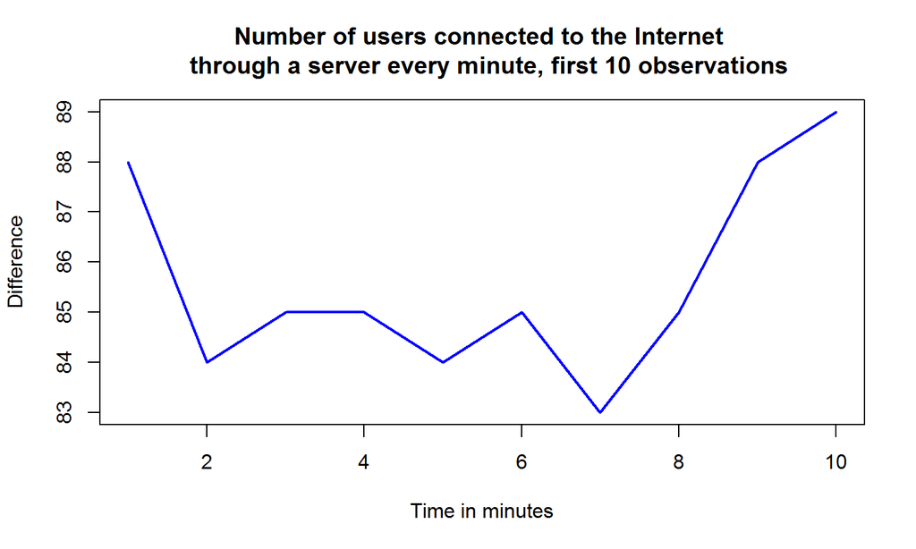

## HairEyeColor: Descriptives

Our second data set is the preinstalled "*HairEyeColor*" data.

The data set includes the variables "Hair, "Eye", "Sex" and "Freq". It has 4 variables and 32 observations, although the sum of individuals included in the data set is 592.

After summing up all individuals with the same eye and hair color, we get the following distribution:

```
##        Eye
## Hair    Brown Blue Hazel Green
##   Black    68   20    15     5
##   Brown   119   84    54    29
##   Red      26   17    14    14
##   Blond     7   94    10    16
```

## HairEyeColor: Visualization

In order to check for a relationship between hair and eye color, we can look at a mosaicplot of the data.

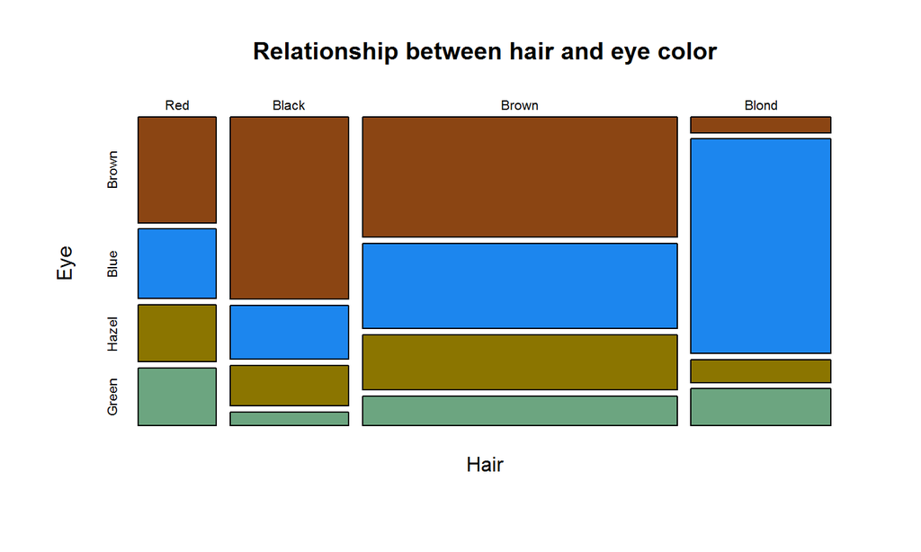